# Introduction to Spatial Analysis

Day 2 - Spatial Operations

Jonathan Phillips

January, 2019

## Transforming Spatial Data

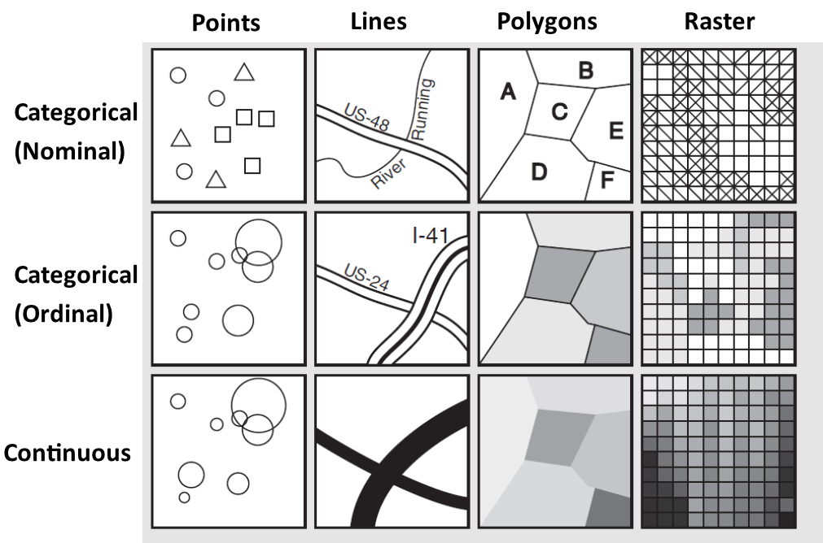

## Transforming Spatial Data

**From Polygons to Points - Centroids**

- How far is it between São Paulo and the other municipalities in São Paulo?
  - We only have the polygon shapefile…

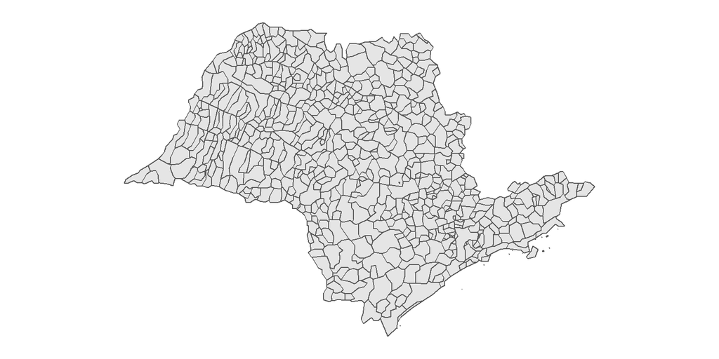

## Transforming Spatial Data

**From Polygons to Points - Centroids**

- How far is it between São Paulo and the other municipalities in São Paulo?
  - We only have the polygon shapefile…

## Transforming Spatial Data

**From Polygons to Points - Centroids**

- How far is it between São Paulo and the other municipalities in São Paulo?
  - A distance *vector*

    |  | V1 |
    | --- | --- |
    | 251 | 456865.66 m |
    | 42 | 556241.51 m |
    | 271 | 419017.83 m |
    | 329 | 655906.86 m |
    | 339 | 593234.52 m |
    | 482 | 38236.42 m |
    | 557 | 180004.40 m |
    | 319 | 340694.71 m |

## Transforming Spatial Data

**From Polygons to Points - Centroids**

## Transforming Spatial Data

**From Points to Polygons - Buffers**

- We want to find the area within 10km of each point

## Transforming Spatial Data

**From Points to Polygons - Buffers**

- We want to find the area within 10km of each point

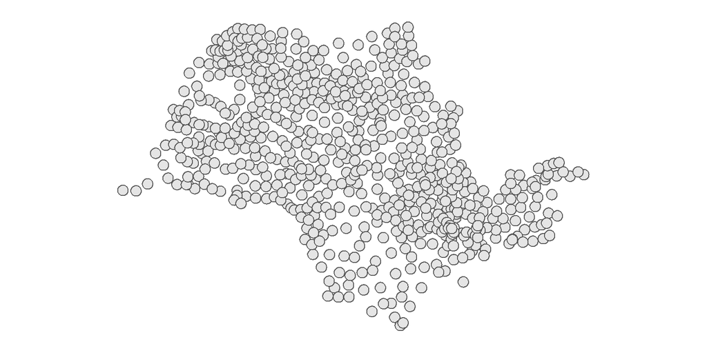

## Transforming Spatial Data

**From Points to Polygons - Voronoi Polygons**

- When we want no gaps between the polygons
  - Each point in space assigned to the nearest centroid

## Transforming Spatial Data

**From Points to Polygons - Voronoi Polygons**

- When we want no gaps between the polygons
  - Each point in space assigned to the nearest centroid

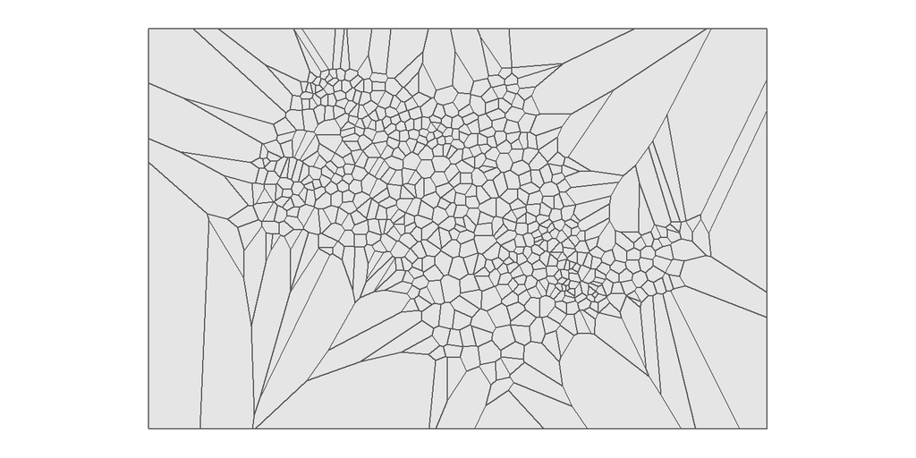

## Transforming Spatial Data

**From Points to Polygons - Voronoi Polygons**

- When we want no gaps between the polygons
  - Each point in space assigned to the nearest centroid

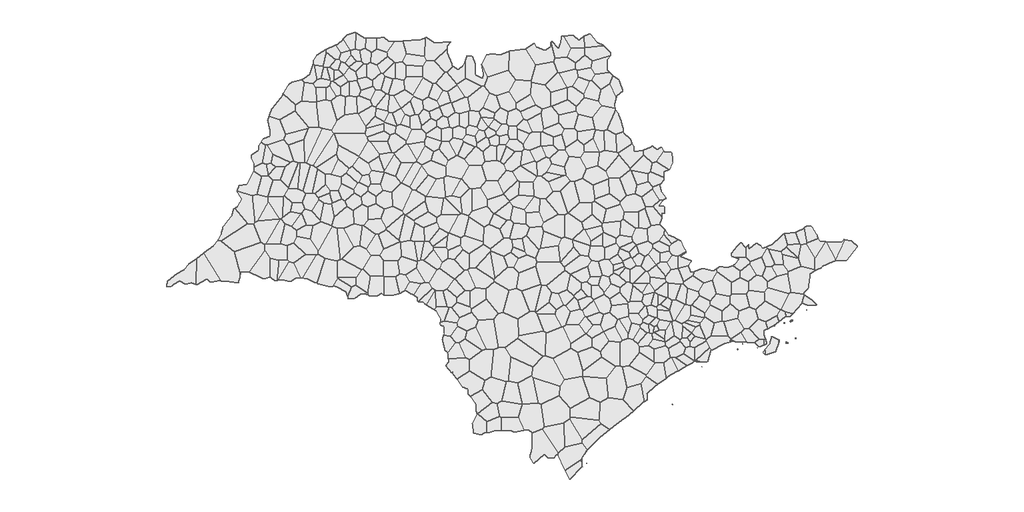

## Transforming Spatial Data

**From Points to Lines - Creating a Graph**

- How would we drive between the top 1% richest municipalities?

## Transforming Spatial Data

**From Points to Lines - Creating a Graph**

- How would we drive between the top 1% richest municipalities?

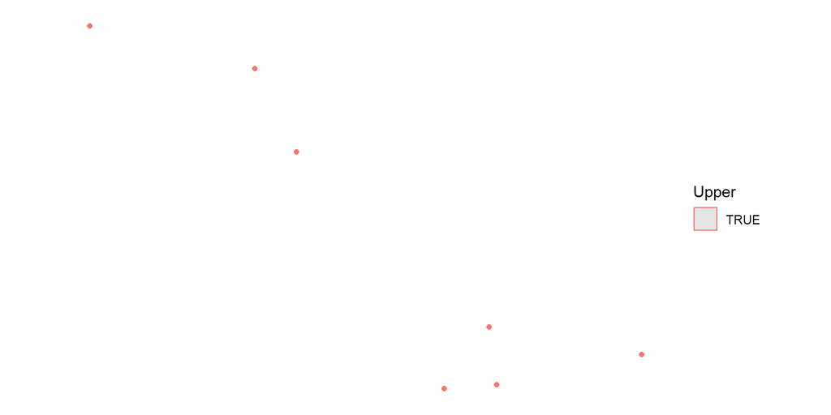

## Transforming Spatial Data

**From Points to Lines - Creating a Graph**

- How would we drive between the top 1% richest municipalities?

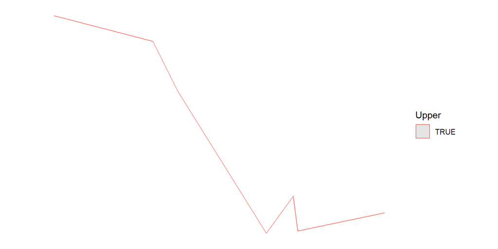

## Transforming Spatial Data

**From Polygons to Lines - Boundaries**

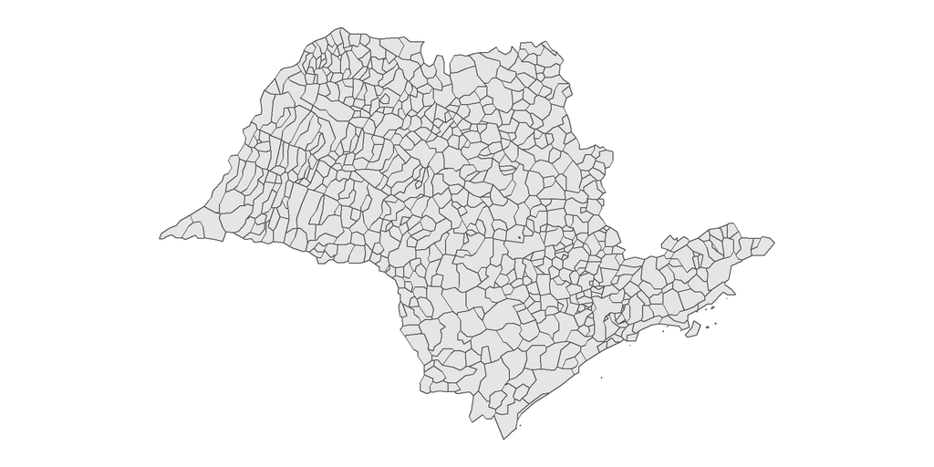

## Transforming Spatial Data

**From Polygons to Lines - Boundaries**

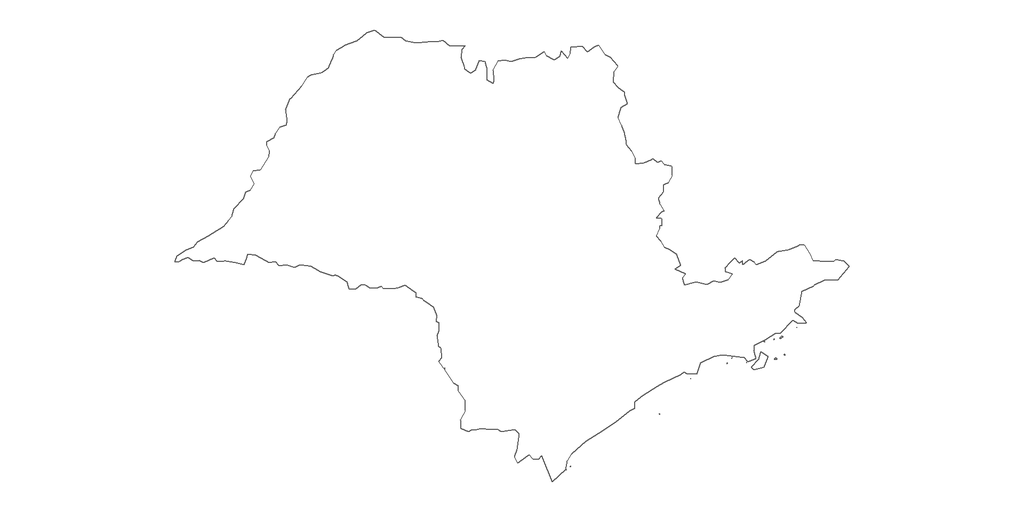

## Transforming Spatial Data

**From Polygons to (bigger) Polygons - Dissolve**

- Aggregating municipal polygons to state polygons by dissolving internal boundaries

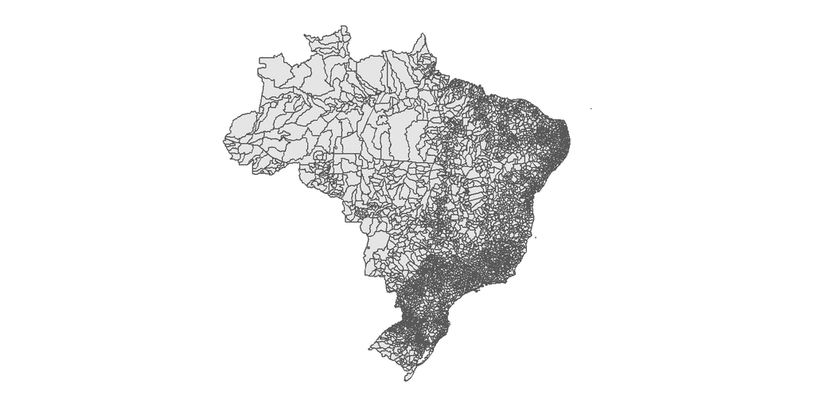

## Transforming Spatial Data

**From Polygons to (bigger) Polygons - Dissolve**

- Aggregating municipal polygons to state polygons by dissolving internal boundaries

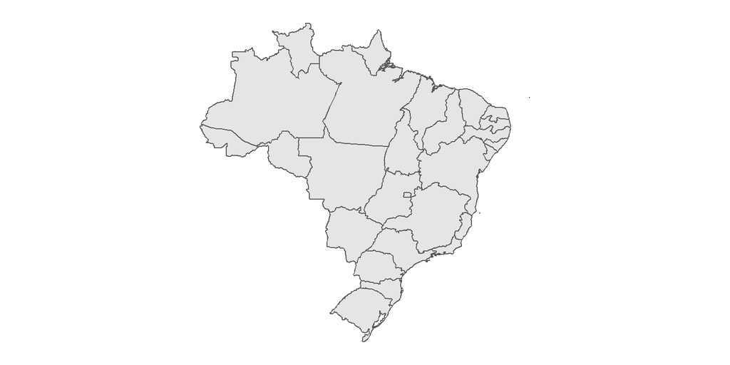

## Transforming Spatial Data

Summary of Transformations:

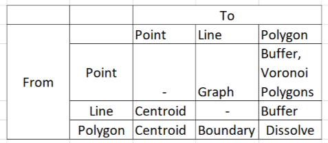

## Layers

- The power of spatial analysis comes from *combining* data sources
  - Spatial + Non-Spatial
  - Spatial + Spatial
- This helps us answer new questions:
  - Where are left-wing votes geographically clustered?
  - Are school results better north or south of the river?
  - Do places with less rainfall suffer more violence?

## Layers

- Spatial layers ‘overlap’ based on their common location attributes
  - CRUCIAL to have the same projection
  - Less important *which* projection
- Handling multiple layers:
  - Hard in Stata
  - Easy in GIS
  - Easy in R

## Layers

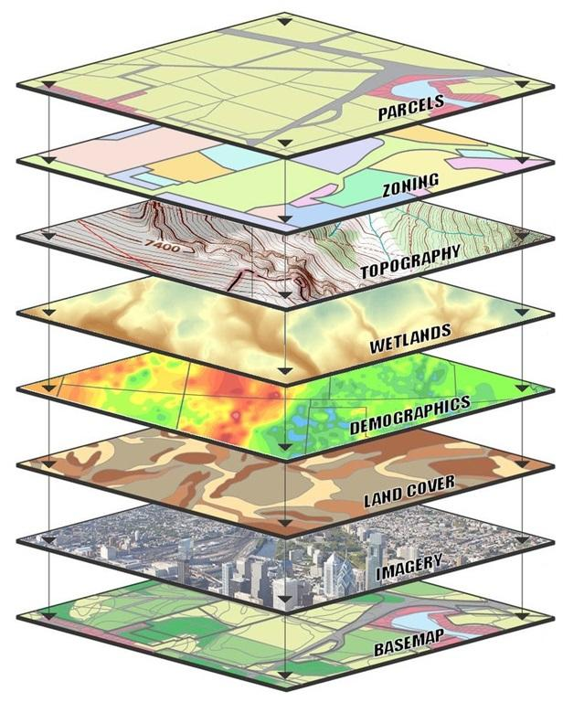

## Non-Spatial Joins

- Governments publish school performance data
  - But what is the *spatial* pattern of school performance?
- We need a source for the location of the schools
- How do we combine the school performance and location datasets?
  - Join on a unique identifier

## Non-Spatial Joins

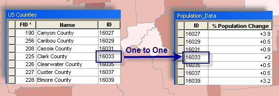

## Spatial Joins

- Do schools located in the cerrado (‘savannah’) perform better than those in other regions?
  - Two spatial data sources: school point locations, and cerrado area
  - Calculation: Average school performance by ecological region
  - But which schools are in which region?
- We need to overlay the schools on the map of the cerrado and ‘add’ the ecological region details to the school dataset

## Spatial Joins

[figure not shown]

## Points in Polygons

- How many earthquakes have occurred in each country?
  - Easy with a spatial join!

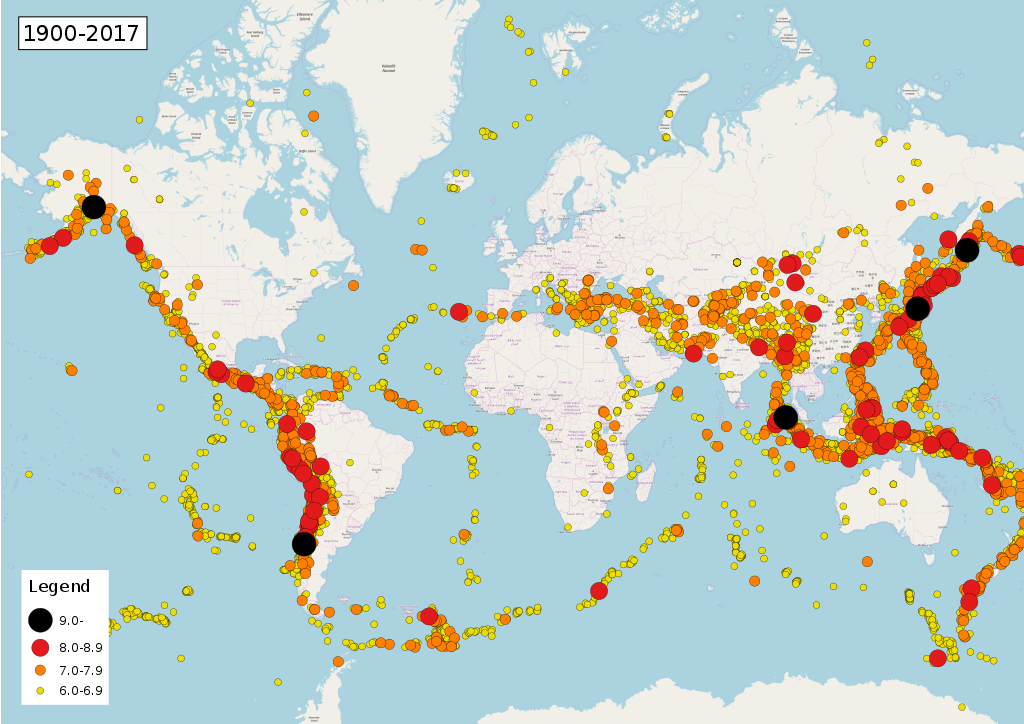

## Points in Polygons

- How many earthquakes have occurred in each country?
  - Easy with a spatial join!

| Country | Number of Earthquakes |
| --- | --- |
| China | 157 |
| Indonesia | 113 |
| Iran | 106 |
| Turkey | 77 |
| Japan | 61 |

## Spatial Relations

- With multiple layers, we can combine them to make *new* spatial objects
  - Not just to share attributes

**Intersection**  
What portion of Minas Gerais is in the cerrado?

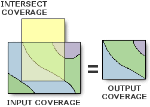

**Union**  
- What land is *either* in Minas Gerais or in the cerrado?

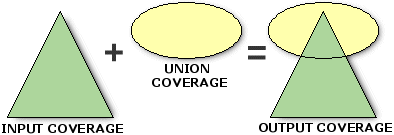

## Example of Spatial Operations

We want to find all the villages within 3km of the Bihar-Jharkhand Border in Bihar

1. Convert village polygons to centroid points